# NOAA Storm Database analysis for U.S. healt and economic consequences due to severe weather events

## Results

### Question 1: Events Most Harmful to Population Health

To determine which types of events are most harmful to population health, we’ll analyze fatalities and injuries.

```r
# Aggregate fatalities and injuries by event type
health_impact <- storm_subset %>%
  group_by(EVTYPE) %>%
  summarize(
    TOTAL_FATALITIES = sum(FATALITIES, na.rm = TRUE),
    TOTAL_INJURIES = sum(INJURIES, na.rm = TRUE),
    TOTAL_CASUALTIES = TOTAL_FATALITIES + TOTAL_INJURIES
  ) %>%
  arrange(desc(TOTAL_CASUALTIES))
# Display top 10 most harmful events for health
top_10_health <- head(health_impact, 10)
kable(top_10_health, caption = "Top 10 Weather Events by Total Casualties")
```

Top 10 Weather Events by Total Casualties

| EVTYPE | TOTAL_FATALITIES | TOTAL_INJURIES | TOTAL_CASUALTIES |
| --- | --- | --- | --- |
| TORNADO | 5633 | 91346 | 96979 |
| EXCESSIVE HEAT | 1903 | 6525 | 8428 |
| TSTM WIND | 504 | 6957 | 7461 |
| FLOOD | 470 | 6789 | 7259 |
| LIGHTNING | 816 | 5230 | 6046 |
| HEAT | 937 | 2100 | 3037 |
| FLASH FLOOD | 978 | 1777 | 2755 |
| ICE STORM | 89 | 1975 | 2064 |
| THUNDERSTORM WIND | 133 | 1488 | 1621 |
| WINTER STORM | 206 | 1321 | 1527 |

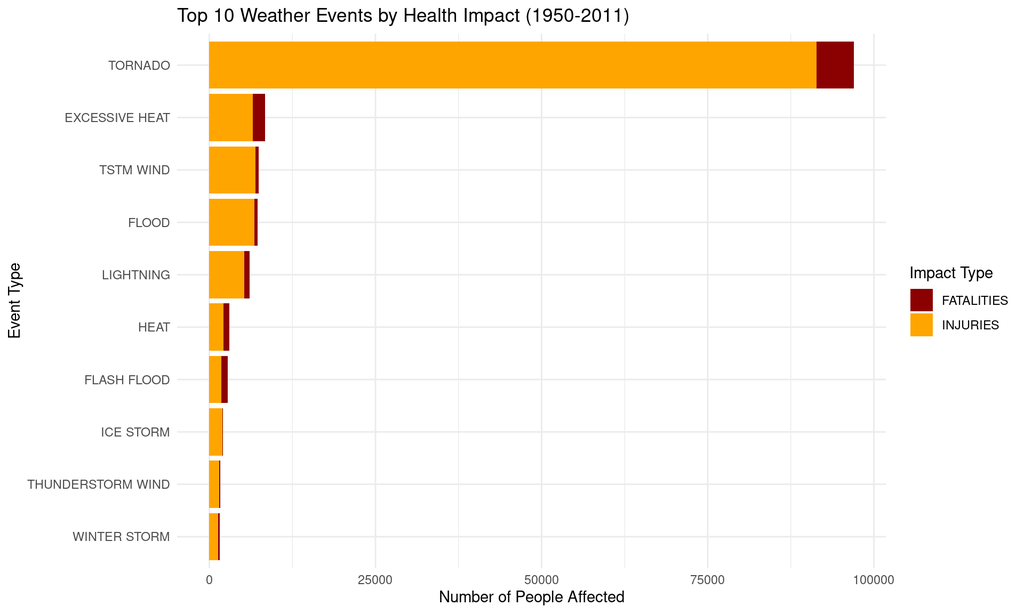

```r
# Create a combined plot for fatalities and injuries
top_10_events <- head(health_impact, 10)$EVTYPE

# Prepare data for visualization
health_plot_data <- storm_subset %>%
  filter(EVTYPE %in% top_10_events) %>%
  group_by(EVTYPE) %>%
  summarize(
    FATALITIES = sum(FATALITIES, na.rm = TRUE),
    INJURIES = sum(INJURIES, na.rm = TRUE)
  ) %>%
  pivot_longer(cols = c(FATALITIES, INJURIES),
               names_to = "IMPACT_TYPE",
               values_to = "COUNT")
# Create the plot
ggplot(health_plot_data, aes(x = reorder(EVTYPE, COUNT), y = COUNT, fill = IMPACT_TYPE)) +
  geom_bar(stat = "identity", position = "stack") +
  coord_flip() +
  labs(
    title = "Top 10 Weather Events by Health Impact (1950-2011)",
    x = "Event Type",
    y = "Number of People Affected",
    fill = "Impact Type"
  ) +
  theme_minimal() +
  scale_fill_manual(values = c("FATALITIES" = "darkred", "INJURIES" = "orange"))
```

Based on the analysis, we can see that tornadoes have by far the most significant impact on population health, causing the highest number of both fatalities and injuries across the United States. Excessive heat, thunderstorm winds, and floods also rank high in terms of their impact on public health.

### Question 2: Events with Greatest Economic Consequences

To determine which events have the greatest economic consequences, we’ll analyze property damage and crop damage.

```r
# Aggregate property and crop damage by event type
economic_impact <- storm_subset %>%
  group_by(EVTYPE) %>%
  summarize(
    PROPERTY_DAMAGE = sum(PROP_DAMAGE, na.rm = TRUE),
    CROP_DAMAGE = sum(CROP_DAMAGE, na.rm = TRUE),
    TOTAL_DAMAGE = sum(TOTAL_DAMAGE, na.rm = TRUE)
  ) %>%
  arrange(desc(TOTAL_DAMAGE))
# Display top 10 most economically damaging events
top_10_economic <- head(economic_impact, 10)
kable(top_10_economic, caption = "Top 10 Weather Events by Total Economic Damage (USD)")
```

Top 10 Weather Events by Total Economic Damage (USD)

| EVTYPE | PROPERTY_DAMAGE | CROP_DAMAGE | TOTAL_DAMAGE |
| --- | --- | --- | --- |
| FLOOD | 144657709807 | 5661968450 | 150319678257 |
| HURRICANE/TYPHOON | 69305840000 | 2607872800 | 71913712800 |
| TORNADO | 56947380616 | 414953270 | 57362333886 |
| STORM SURGE | 43323536000 | 5000 | 43323541000 |
| HAIL | 15735267513 | 3025954473 | 18761221986 |
| FLASH FLOOD | 16822673978 | 1421317100 | 18243991078 |
| DROUGHT | 1046106000 | 13972566000 | 15018672000 |
| HURRICANE | 11868319010 | 2741910000 | 14610229010 |
| RIVER FLOOD | 5118945500 | 5029459000 | 10148404500 |
| ICE STORM | 3944927860 | 5022113500 | 8967041360 |

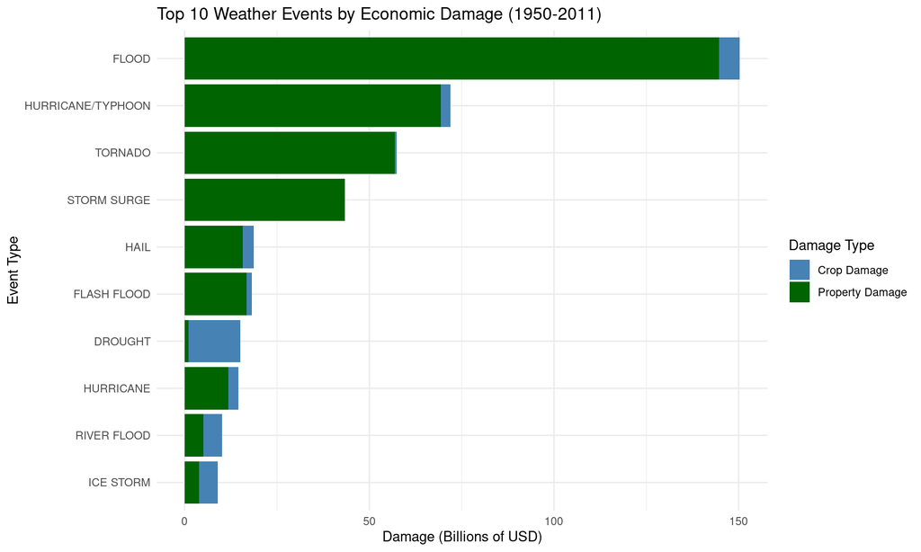

```r
# Format in billions for better readability
top_10_economic_billions <- top_10_economic %>%
  mutate(across(PROPERTY_DAMAGE:TOTAL_DAMAGE,
                ~round(. / 1e9, 2),
                .names = "{col}_BILLIONS"))

# Prepare data for visualization
economic_plot_data <- top_10_economic %>%
  select(EVTYPE, PROPERTY_DAMAGE, CROP_DAMAGE) %>%
  pivot_longer(cols = c(PROPERTY_DAMAGE, CROP_DAMAGE),
               names_to = "DAMAGE_TYPE",
               values_to = "AMOUNT")

# Create the plot
ggplot(economic_plot_data, aes(x = reorder(EVTYPE, AMOUNT), y = AMOUNT / 1e9, fill = DAMAGE_TYPE)) +
  geom_bar(stat = "identity", position = "stack") +
  coord_flip() +
  labs(
    title = "Top 10 Weather Events by Economic Damage (1950-2011)",
    x = "Event Type",
    y = "Damage (Billions of USD)",
    fill = "Damage Type"
  ) +
  theme_minimal() +
  scale_fill_manual(values = c("PROPERTY_DAMAGE" = "darkgreen", "CROP_DAMAGE" = "steelblue"),
                    labels = c("Crop Damage", "Property Damage"))
```

The analysis shows that floods cause the greatest economic damage overall, followed by hurricanes/typhoons and tornadoes. When looking specifically at crop damage, drought has the most substantial impact, highlighting how different types of extreme weather events affect various sectors of the economy differently.